# Laboratório R

### Padrões e modelos

Carregando o pacote “modelr” para remover a relação muito forte entre preço e quilate para que possamos explorar as sutilezas que permanecem. Com o pacote, usamos a função lm (fitting linear models) para realizar regressão linear.

```
##
## Call:
## lm(formula = log(price) ~ log(carat), data = diamonds)
##
## Coefficients:
## (Intercept)   log(carat)
##       8.449        1.676
```

| carat | cut | color | clarity | depth | table | price | x | y | z | resid |
| --- | --- | --- | --- | --- | --- | --- | --- | --- | --- | --- |
| 0.23 | Ideal | E | SI2 | 61.5 | 55.0 | 326 | 3.95 | 3.98 | 2.43 | 0.8196681 |
| 0.21 | Premium | E | SI1 | 59.8 | 61.0 | 326 | 3.89 | 3.84 | 2.31 | 0.9546565 |
| 0.23 | Good | E | VS1 | 56.9 | 65.0 | 327 | 4.05 | 4.07 | 2.31 | 0.8221824 |
| 0.29 | Premium | I | VS2 | 62.4 | 58.0 | 334 | 4.20 | 4.23 | 2.63 | 0.5694586 |
| 0.31 | Good | J | SI2 | 63.3 | 58.0 | 335 | 4.34 | 4.35 | 2.75 | 0.5107668 |
| 0.24 | Very Good | J | VVS2 | 62.8 | 57.0 | 336 | 3.94 | 3.96 | 2.48 | 0.7866561 |
| 0.24 | Very Good | I | VVS1 | 62.3 | 57.0 | 336 | 3.95 | 3.98 | 2.47 | 0.7866561 |
| 0.26 | Very Good | H | SI1 | 61.9 | 55.0 | 337 | 4.07 | 4.11 | 2.53 | 0.6899548 |
| 0.22 | Fair | E | VS2 | 65.1 | 61.0 | 337 | 3.87 | 3.78 | 2.49 | 0.9128559 |
| 0.23 | Very Good | H | VS1 | 59.4 | 61.0 | 338 | 4.00 | 4.05 | 2.39 | 0.8498399 |
| 0.30 | Good | J | SI1 | 64.0 | 55.0 | 339 | 4.25 | 4.28 | 2.73 | 0.5460619 |
| 0.23 | Ideal | J | VS1 | 62.8 | 56.0 | 340 | 3.93 | 3.90 | 2.46 | 0.8548686 |
| 0.22 | Premium | F | SI1 | 60.4 | 61.0 | 342 | 3.88 | 3.84 | 2.33 | 0.9263998 |
| 0.31 | Ideal | J | SI2 | 62.2 | 54.0 | 344 | 4.35 | 4.37 | 2.71 | 0.5244889 |
| 0.20 | Premium | E | SI2 | 60.2 | 62.0 | 345 | 3.79 | 3.75 | 2.27 | 1.0963721 |
| 0.32 | Premium | E | I1 | 60.9 | 58.0 | 345 | 4.38 | 4.42 | 2.68 | 0.4987585 |
| 0.30 | Ideal | I | SI2 | 62.0 | 54.0 | 348 | 4.31 | 4.34 | 2.68 | 0.5605592 |
| 0.30 | Good | J | SI1 | 63.4 | 54.0 | 351 | 4.23 | 4.29 | 2.70 | 0.5653916 |
| 0.30 | Good | J | SI1 | 63.8 | 56.0 | 351 | 4.23 | 4.26 | 2.71 | 0.5653916 |
| 0.30 | Very Good | J | SI1 | 62.7 | 59.0 | 351 | 4.21 | 4.27 | 2.66 | 0.5653916 |
| 0.30 | Good | I | SI2 | 63.3 | 56.0 | 351 | 4.26 | 4.30 | 2.71 | 0.5653916 |
| 0.23 | Very Good | E | VS2 | 63.8 | 55.0 | 352 | 3.85 | 3.92 | 2.48 | 0.8850404 |
| 0.23 | Very Good | H | VS1 | 61.0 | 57.0 | 353 | 3.94 | 3.96 | 2.41 | 0.8875547 |
| 0.31 | Very Good | J | SI1 | 59.4 | 62.0 | 353 | 4.39 | 4.43 | 2.62 | 0.5382110 |
| 0.31 | Very Good | J | SI1 | 58.1 | 62.0 | 353 | 4.44 | 4.47 | 2.59 | 0.5382110 |
| 0.23 | Very Good | G | VVS2 | 60.4 | 58.0 | 354 | 3.97 | 4.01 | 2.41 | 0.8900690 |
| 0.24 | Premium | I | VS1 | 62.5 | 57.0 | 355 | 3.97 | 3.94 | 2.47 | 0.8311396 |
| 0.30 | Very Good | J | VS2 | 62.2 | 57.0 | 357 | 4.28 | 4.30 | 2.67 | 0.5750564 |
| 0.23 | Very Good | D | VS2 | 60.5 | 61.0 | 357 | 3.96 | 3.97 | 2.40 | 0.8976120 |
| 0.23 | Very Good | F | VS1 | 60.9 | 57.0 | 357 | 3.96 | 3.99 | 2.42 | 0.8976120 |

[output cut: 70 more lines]

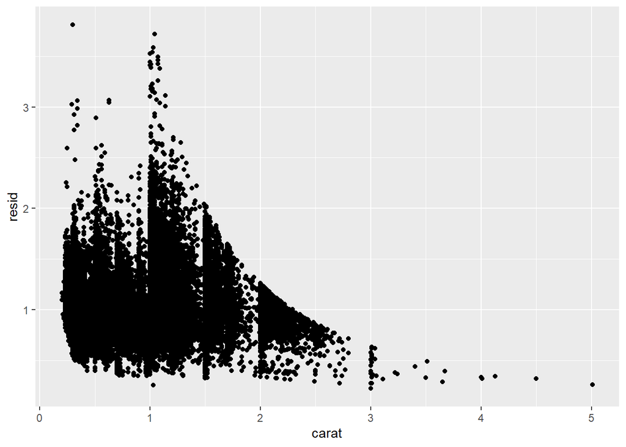

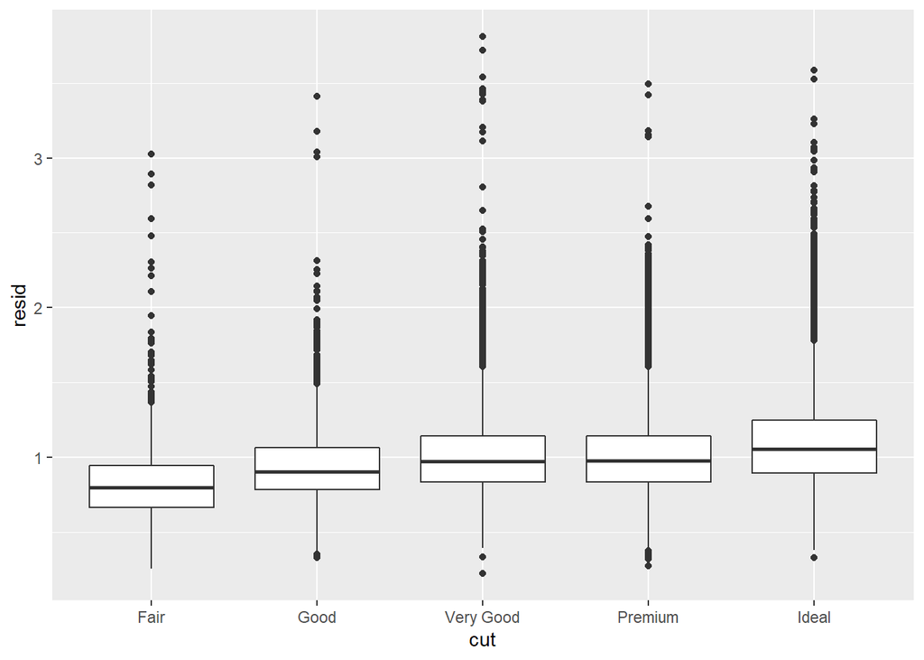

## Laboratório 6

### Lendo Arquivos CSV

heights.csv

| earn | height | sex | ed | age | race |
| --- | --- | --- | --- | --- | --- |
| 50000 | 74.42444 | male | 16 | 45 | white |
| 60000 | 65.53754 | female | 16 | 58 | white |
| 30000 | 63.62920 | female | 16 | 29 | white |
| 50000 | 63.10856 | female | 16 | 91 | other |
| 51000 | 63.40248 | female | 17 | 39 | white |
| 9000 | 64.39951 | female | 15 | 26 | white |
| 29000 | 61.65633 | female | 12 | 49 | white |
| 32000 | 72.69854 | male | 17 | 46 | white |
| 2000 | 72.03947 | male | 15 | 21 | hispanic |
| 27000 | 72.23493 | male | 12 | 26 | white |
| 6530 | 69.51215 | male | 16 | 65 | white |
| 30000 | 68.03161 | male | 11 | 34 | white |
| 12000 | 67.55693 | male | 12 | 27 | white |
| 12000 | 65.43059 | female | 12 | 51 | white |
| 22000 | 65.66285 | female | 16 | 35 | white |
| 17000 | 67.75877 | male | 12 | 58 | white |
| 40000 | 68.35184 | female | 14 | 29 | white |
| 44000 | 69.60957 | male | 13 | 44 | white |
| 7000 | 64.18457 | female | 12 | 55 | black |
| 53000 | 73.07461 | male | 13 | 35 | black |

csv inline read_csv(“a,b,c 1,2,3 4,5,6”)

| a | b | c |
| --- | --- | --- |
| 1 | 2 | 3 |
| 4 | 5 | 6 |

A primeira linha de metadados A segunda linha de metadados

| x | y | z |
| --- | --- | --- |
| 1 | 2 | 3 |

“# Um comentário que eu quero pular”

| x | y | z |
| --- | --- | --- |
| 1 | 2 | 3 |

read_csv(“1,2,34,5,6”, col_names = FALSE)

| X1 | X2 | X3 |
| --- | --- | --- |
| 1 | 2 | 3 |
| 4 | 5 | 6 |

read_csv(“1,2,34,5,6”, col_names = c(“x”, “y”, “z”))

| x | y | z |
| --- | --- | --- |
| 1 | 2 | 3 |
| 4 | 5 | 6 |

read_csv(“a,b,c1,2,?”, na = “?”)

| a | b | c |
| --- | --- | --- |
| 1 | 2 | NA |

### Fatores

```
## [1] "Abr" "Dec" "Jan" "Mar"
```

```
## [1] <NA> Abr  Jan  Mar
## Levels: Jan Fev Mar Abr Mai Jun Jul Ago Set Out Nov Dez
```

```
## [1] Jan Mar Abr
## Levels: Jan Fev Mar Abr Mai Jun Jul Ago Set Out Nov Dez
```

```
## [1] Dez  Abr  <NA> Mar
## Levels: Jan Fev Mar Abr Mai Jun Jul Ago Set Out Nov Dez
```

```
## [1] Dec Abr Jan Mar
## Levels: Dec Abr Jan Mar
```

```
## [1] Dec Abr Jan Mar
## Levels: Dec Abr Jan Mar
```

### Conclusão Laboratório 6